# Homework 3

Group 1

9/23/2021

## Homework 3

## Load Data

```r
loans <- readr::read_csv('https://raw.githubusercontent.com/christianthieme/Machine_Learning_Big_Data/main/HW3/Loan_approval.csv')
```

## Exploratory Data Analysis

To begin our exploratory data analysis, we’ll begin by taking a high level look at our dataset:

```r
glimpse(loans)
```

```
## Observations: 614
## Variables: 13
## $ Loan_ID           <chr> "LP001002", "LP001003", "LP001005", "LP001006"…
## $ Gender            <chr> "Male", "Male", "Male", "Male", "Male", "Male"…
## $ Married           <chr> "No", "Yes", "Yes", "Yes", "No", "Yes", "Yes",…
## $ Dependents        <chr> "0", "1", "0", "0", "0", "2", "0", "3+", "2", …
## $ Education         <chr> "Graduate", "Graduate", "Graduate", "Not Gradu…
## $ Self_Employed     <chr> "No", "No", "Yes", "No", "No", "Yes", "No", "N…
## $ ApplicantIncome   <dbl> 5849, 4583, 3000, 2583, 6000, 5417, 2333, 3036…
## $ CoapplicantIncome <dbl> 0, 1508, 0, 2358, 0, 4196, 1516, 2504, 1526, 1…
## $ LoanAmount        <dbl> NA, 128, 66, 120, 141, 267, 95, 158, 168, 349,…
## $ Loan_Amount_Term  <dbl> 360, 360, 360, 360, 360, 360, 360, 360, 360, 3…
## $ Credit_History    <dbl> 1, 1, 1, 1, 1, 1, 1, 0, 1, 1, 1, 1, 1, 1, 1, 1…
## $ Property_Area     <chr> "Urban", "Rural", "Urban", "Urban", "Urban", "…
## $ Loan_Status       <chr> "Y", "N", "Y", "Y", "Y", "Y", "Y", "N", "Y", "…
```

From this view we can see that this dataset has 614 rows and 13 columns. There is a mix of both numeric and categorical data, although it appears that at least one numeric column should actually be categorical.

## Summary Statistics

Continuous and categorical variables were summarized separately for the sake of clarity.

|  | n | min | mean | median | max | sd |
| --- | --- | --- | --- | --- | --- | --- |
| ApplicantIncome | 614 | 150 | 5403.4593 | 3812.5 | 81000 | 6109.04167 |
| CoapplicantIncome | 614 | 0 | 1621.2458 | 1188.5 | 41667 | 2926.24837 |
| LoanAmount | 592 | 9 | 146.4122 | 128.0 | 700 | 85.58733 |
| Loan_Amount_Term | 600 | 12 | 342.0000 | 360.0 | 480 | 65.12041 |

`Dependents` and `Property_Area` each comprise multiple categories. On the other hand, `Gender`, `Married`, `Education`, `Self_Employed`, `Credit_History`, `Loan_Status` are all binaries.

Summary statistics for Categorical Variables

|  | Dependents | Property_Area |
| --- | --- | --- |
|  | 0 :345 | Rural :179 |
|  | 1 :102 | Semiurban:233 |
|  | 2 :101 | Urban :202 |
|  | 3+ : 51 | NA |
|  | NA’s: 15 | NA |

Summary statistics for Binary Categorical Variables

|  | Gender | Married | Education | Self_Employed | Credit_History | Loan_Status |
| --- | --- | --- | --- | --- | --- | --- |
|  | Female:112 | No :213 | Graduate :480 | No :500 | 0 : 89 | N:192 |
|  | Male :489 | Yes :398 | Not Graduate:134 | Yes : 82 | 1 :475 | Y:422 |
|  | NA’s : 13 | NA’s: 3 | NA | NA’s: 32 | NA’s: 50 | NA |

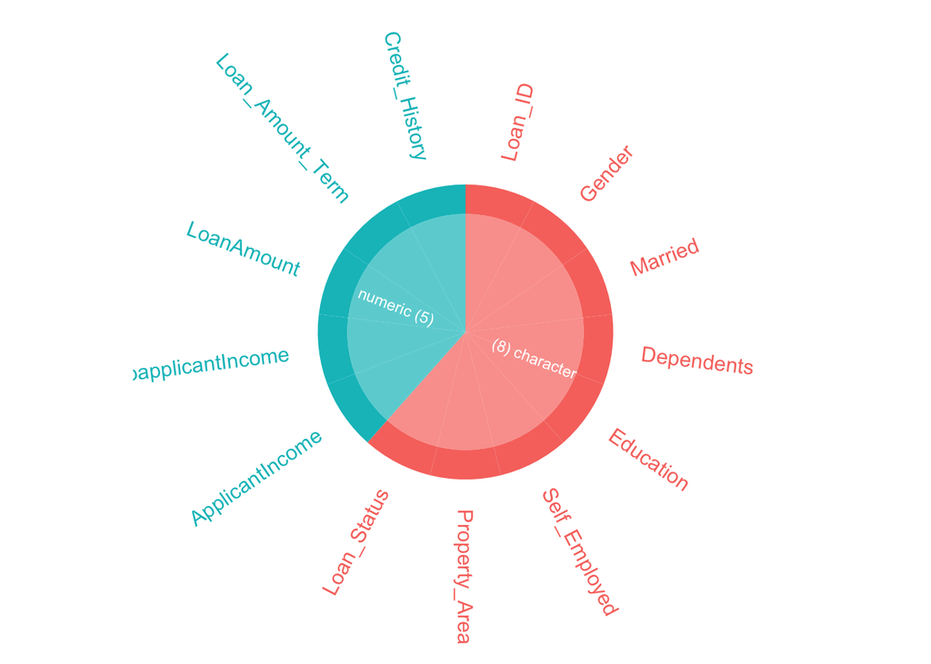

```r
inspectdf::inspect_types(loans) %>%
  show_plot
```

The data appears to have some missing values that we’ll have to deal with as we move along.

Since we know there are missing values, let’s see how pervasive the issue is:

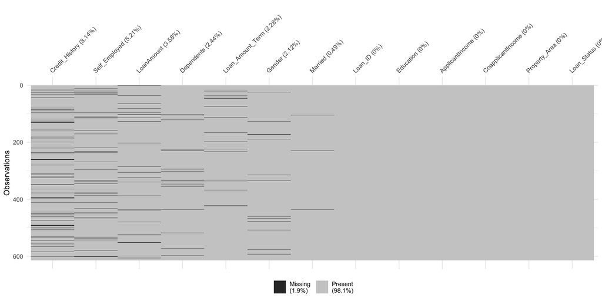

```r
visdat::vis_miss(loans, sort_miss = TRUE)
```

7 columns have missing data, ranging from 0.49% to 8.14%. What’s interesting is there are 22 instances where `LoanAmount` is missing. In total, ~2% of the data has missing values.

Let’s now inspect our numeric features:

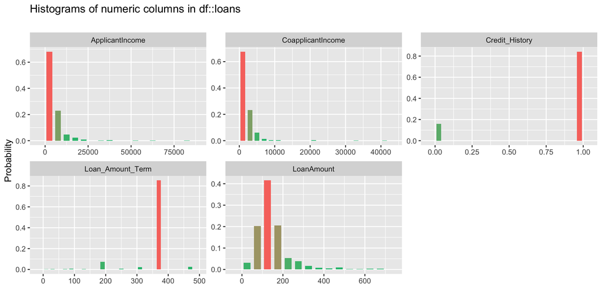

```r
inspectdf::inspect_num(loans) %>%
 show_plot()
```

Now, let’s turn our attention to our categorical variables. We’ll first look to see what percentage each category within a given variable makes up:

```r
inspectdf::inspect_imb(loans %>% select(-Loan_ID))
```

```
## # A tibble: 7 x 4
##   col_name      value      pcnt   cnt
##   <chr>         <chr>     <dbl> <int>
## 1 Self_Employed No         81.4   500
## 2 Gender        Male       79.6   489
## 3 Education     Graduate   78.2   480
## 4 Loan_Status   Y          68.7   422
## 5 Married       Yes        64.8   398
## 6 Dependents    0          56.2   345
## 7 Property_Area Semiurban  37.9   233
```

While the table above is insightful, it’s also helpful to view it in a visual format:

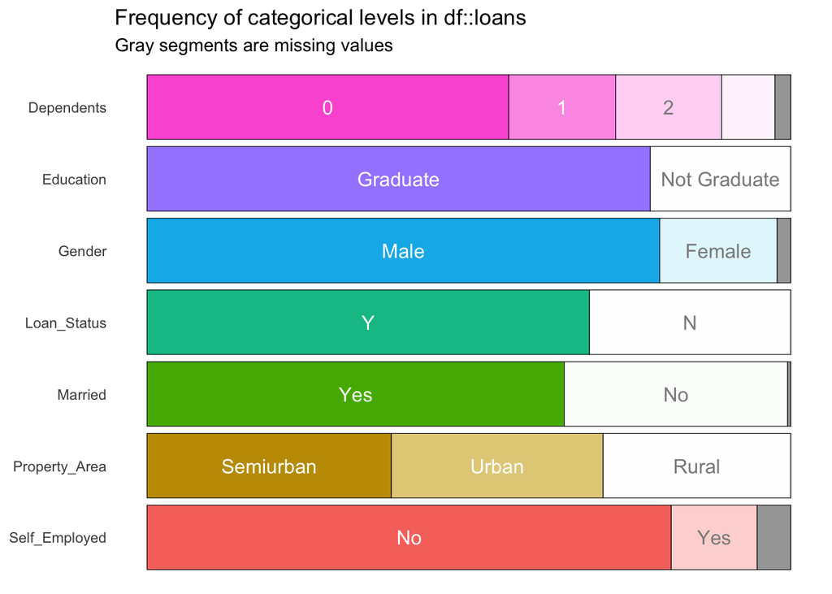

```r
inspect_cat(loans %>% select(-Loan_ID)) %>%
  show_plot()
```

Some very interesting points about the demographic we are looking at come as we look at this visual:

- Half of the population do not have any dependents
- Most people in this dataset are graduates
- Over 75% of the population is male
- 65% of the population is married
- Most of the individuals are not self-employed

## Summary Statistics Graphs

The shapes of the distributions of the continuous variables are similar for both target values for all predictors. There does not seem to be a significant difference between those who get loan approval and those who do not for any of the predictors.

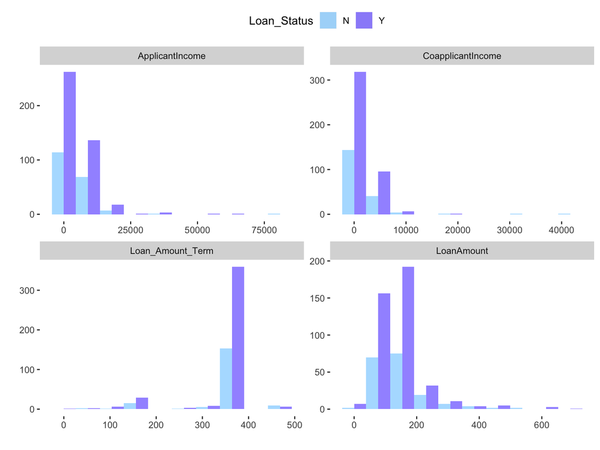

Numeric Data Distributions as a Function of Loan_Status

Examining the dispersion of approval status between variables, it looks like likelihoods are higher for applicants who have credit history and who are maried and live in Semiurban area; as well as for those with graduate degree.

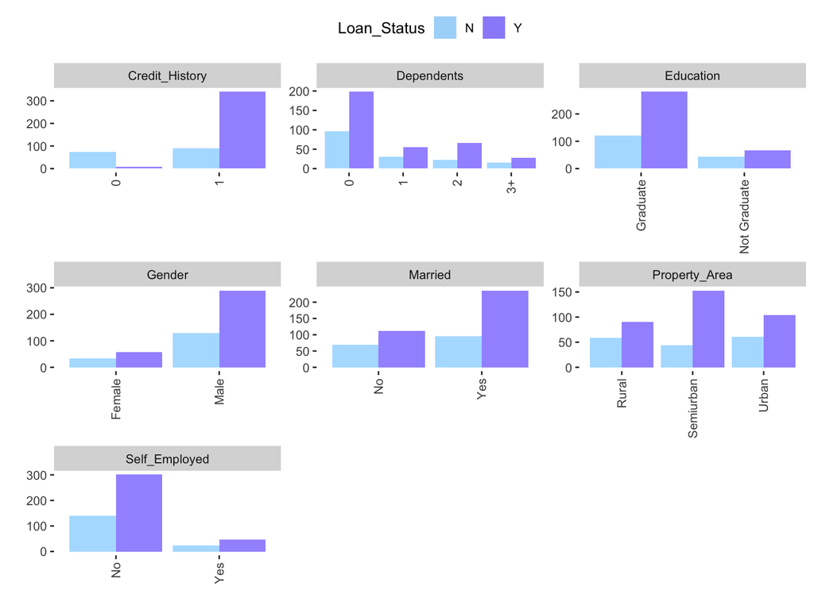

Categorical Data Distributions as a Function of Loan_Status